# Examining the Online News Industry and Its Link To Social Media Sharing and Popularity

Samuel Sherman

July 18th, 2015

The news articles are the top articles for July 18th, 2015 (today). Therefore the facebook and twitter share counts may be relatively low, as compared to an analysis of articles that may have been from a later date.

```python
%matplotlib inline
import requests
import pandas as pd
import csv
import numpy as np
import matplotlib.pyplot as plt
```

Using alltop.com's most popular stories (http://most-popular.alltop.com/) for url's and the api's for Facebook and Twitter on statisical information on the sharing, commenting, viewing, I aquired useful information on today's most popular articles and their spread accross social media.

```python
# NEW YOR TIMES
# 1 http://www.nytimes.com/2015/07/19/world/stowaway-crime-scofflaw-ship.html
# 2 http://www.nytimes.com/2015/07/21/health/hipaas-use-as-code-of-silence-often-misinterprets-the-law.html
# 3 http://www.nytimes.com/2015/07/19/fashion/divorce-salons-workshops-coaches-help-women-navigate-their-divorces.html
# 4 http://www.nytimes.com/2015/07/18/us/brush-fire-sweeps-across-crowded-freeway-in-southern-california.html
# 5 http://www.nytimes.com/2015/07/18/opinion/stars-on-baseballs-horizon.html
nytFcbk1 = requests.get('https://api.facebook.com/method/links.getStats?urls=http://www.nytimes.com/2015/07/19/world/stowaway-crime-scofflaw-ship.html&format=json').json()[0]
nytTwtr1 = requests.get('http://urls.api.twitter.com/1/urls/count.json?url=http://www.nytimes.com/2015/07/19/world/stowaway-crime-scofflaw-ship.html').json()

nytFcbk2 = requests.get('https://api.facebook.com/method/links.getStats?urls=http://www.nytimes.com/2015/07/21/health/hipaas-use-as-code-of-silence-often-misinterprets-the-law.html&format=json').json()[0]
nytTwtr2 = requests.get('http://urls.api.twitter.com/1/urls/count.json?url=http://www.nytimes.com/2015/07/21/health/hipaas-use-as-code-of-silence-often-misinterprets-the-law.html').json()

nytFcbk3 = requests.get('https://api.facebook.com/method/links.getStats?urls=http://www.nytimes.com/2015/07/19/fashion/divorce-salons-workshops-coaches-help-women-navigate-their-divorces.html&format=json').json()[0]
nytTwtr3 = requests.get('http://urls.api.twitter.com/1/urls/count.json?url=http://www.nytimes.com/2015/07/19/fashion/divorce-salons-workshops-coaches-help-women-navigate-their-divorces.html').json()

nytFcbk4 = requests.get('https://api.facebook.com/method/links.getStats?urls=http://www.nytimes.com/2015/07/18/us/brush-fire-sweeps-across-crowded-freeway-in-southern-california.html&format=json').json()[0]
nytTwtr4 = requests.get('http://urls.api.twitter.com/1/urls/count.json?url=http://www.nytimes.com/2015/07/18/us/brush-fire-sweeps-across-crowded-freeway-in-southern-california.html').json()

nytFcbk5 = requests.get('https://api.facebook.com/method/links.getStats?urls=http://www.nytimes.com/2015/07/18/opinion/stars-on-baseballs-horizon.html&format=json').json()[0]
nytTwtr5 = requests.get('http://urls.api.twitter.com/1/urls/count.json?url=http://www.nytimes.com/2015/07/18/opinion/stars-on-baseballs-horizon.html').json()
```

```python
# FORBES top 5
# 1 http://www.forbes.com/sites/insertcoin/2015/07/18/glamorizing-the-wii-us-failure-does-nintendo-a-disservice/
# 2 http://www.forbes.com/sites/ewanspence/2015/07/18/jolla-licences-sailfish-os-2-0/
# 3 http://www.forbes.com/sites/scottmendelson/2015/07/18/box-office-ant-man-nabs-second-smallest-marvel-friday-with-22-6m/
# 4 http://www.forbes.com/sites/timworstall/2015/07/18/krugmans-mistake-to-move-walmart-to-costcos-wage-model-would-destroy-700000-jobs/
# 5 http://www.forbes.com/sites/lizryan/2015/07/18/how-maria-lost-a-job-offer-and-dodged-a-bullet/
forbFcbk1 = requests.get('https://api.facebook.com/method/links.getStats?urls=http://www.forbes.com/sites/insertcoin/2015/07/18/glamorizing-the-wii-us-failure-does-nintendo-a-disservice/&format=json').json()[0]
forbTwtr1 = requests.get('http://urls.api.twitter.com/1/urls/count.json?url=http://www.forbes.com/sites/insertcoin/2015/07/18/glamorizing-the-wii-us-failure-does-nintendo-a-disservice/').json()

forbFcbk2 = requests.get('https://api.facebook.com/method/links.getStats?urls=http://www.forbes.com/sites/ewanspence/2015/07/18/jolla-licences-sailfish-os-2-0/&format=json').json()[0]
forbTwtr2 = requests.get('http://urls.api.twitter.com/1/urls/count.json?url=http://www.forbes.com/sites/ewanspence/2015/07/18/jolla-licences-sailfish-os-2-0/').json()

forbFcbk3 = requests.get('https://api.facebook.com/method/links.getStats?urls=http://www.forbes.com/sites/scottmendelson/2015/07/18/box-office-ant-man-nabs-second-smallest-marvel-friday-with-22-6m/&format=json').json()[0]
forbTwtr3 = requests.get('http://urls.api.twitter.com/1/urls/count.json?url=http://www.forbes.com/sites/scottmendelson/2015/07/18/box-office-ant-man-nabs-second-smallest-marvel-friday-with-22-6m/').json()

forbFcbk4 = requests.get('https://api.facebook.com/method/links.getStats?urls=http://www.forbes.com/sites/timworstall/2015/07/18/krugmans-mistake-to-move-walmart-to-costcos-wage-model-would-destroy-700000-jobs/&format=json').json()[0]
forbTwtr4 = requests.get('http://urls.api.twitter.com/1/urls/count.json?url=http://www.forbes.com/sites/timworstall/2015/07/18/krugmans-mistake-to-move-walmart-to-costcos-wage-model-would-destroy-700000-jobs/').json()

forbFcbk5 = requests.get('https://api.facebook.com/method/links.getStats?urls=http://www.forbes.com/sites/lizryan/2015/07/18/how-maria-lost-a-job-offer-and-dodged-a-bullet/&format=json').json()[0]
forbTwtr5 = requests.get('http://urls.api.twitter.com/1/urls/count.json?url=http://www.forbes.com/sites/lizryan/2015/07/18/how-maria-lost-a-job-offer-and-dodged-a-bullet/').json()
```

```python
# NPR top 5
# 1 http://www.npr.org/sections/thetwo-way/2015/07/18/424131021/irans-khamenei-signals-approval-of-nuclear-deal-with-arrogant-u-s?utm_medium=RSS&utm_campaign=storiesfromnpr
# 2 http://www.npr.org/sections/thetwo-way/2015/07/18/424122976/greeces-ex-finance-minister-bailout-reforms-will-fail?utm_medium=RSS&utm_campaign=storiesfromnpr
# 3 http://www.npr.org/2015/07/18/423894700/from-highways-to-trade-deal-what-big-business-wants-by-christmas?utm_medium=RSS&utm_campaign=storiesfromnpr
# 4 http://www.npr.org/2015/07/18/418600412/the-waters-of-lagoon-are-choppy-but-enthralling?utm_medium=RSS&utm_campaign=storiesfromnpr
# 5 http://www.npr.org/2015/07/18/423616883/not-my-job-shirley-jones-gets-quizzed-on-partridge-shooting?utm_medium=RSS&utm_campaign=storiesfromnpr
nprFcbk1 = requests.get('https://api.facebook.com/method/links.getStats?urls=http://www.npr.org/sections/thetwo-way/2015/07/18/424131021/irans-khamenei-signals-approval-of-nuclear-deal-with-arrogant-u-s?utm_medium=RSS&utm_campaign=storiesfromnpr&format=json').json()[0]
nprTwtr1 = requests.get('http://urls.api.twitter.com/1/urls/count.json?url=http://www.npr.org/sections/thetwo-way/2015/07/18/424131021/irans-khamenei-signals-approval-of-nuclear-deal-with-arrogant-u-s?utm_medium=RSS&utm_campaign=storiesfromnpr').json()

nprFcbk2 = requests.get('https://api.facebook.com/method/links.getStats?urls=http://www.npr.org/sections/thetwo-way/2015/07/18/424122976/greeces-ex-finance-minister-bailout-reforms-will-fail?utm_medium=RSS&utm_campaign=storiesfromnpr&format=json').json()[0]
nprTwtr2 = requests.get('http://urls.api.twitter.com/1/urls/count.json?url=http://www.npr.org/sections/thetwo-way/2015/07/18/424122976/greeces-ex-finance-minister-bailout-reforms-will-fail?utm_medium=RSS&utm_campaign=storiesfromnpr').json()

nprFcbk3 = requests.get('https://api.facebook.com/method/links.getStats?urls=http://www.npr.org/2015/07/18/423894700/from-highways-to-trade-deal-what-big-business-wants-by-christmas?utm_medium=RSS&utm_campaign=storiesfromnpr&format=json').json()[0]
nprTwtr3 = requests.get('http://urls.api.twitter.com/1/urls/count.json?url=http://www.npr.org/2015/07/18/423894700/from-highways-to-trade-deal-what-big-business-wants-by-christmas?utm_medium=RSS&utm_campaign=storiesfromnpr').json()

nprFcbk4 = requests.get('https://api.facebook.com/method/links.getStats?urls=http://www.npr.org/2015/07/18/418600412/the-waters-of-lagoon-are-choppy-but-enthralling?utm_medium=RSS&utm_campaign=storiesfromnpr&format=json').json()[0]
nprTwtr4 = requests.get('http://urls.api.twitter.com/1/urls/count.json?url=http://www.npr.org/2015/07/18/418600412/the-waters-of-lagoon-are-choppy-but-enthralling?utm_medium=RSS&utm_campaign=storiesfromnpr').json()

nprFcbk5 = requests.get('https://api.facebook.com/method/links.getStats?urls=http://www.npr.org/2015/07/18/423616883/not-my-job-shirley-jones-gets-quizzed-on-partridge-shooting?utm_medium=RSS&utm_campaign=storiesfromnpr&format=json').json()[0]
nprTwtr5 = requests.get('http://urls.api.twitter.com/1/urls/count.json?url=http://www.npr.org/2015/07/18/423616883/not-my-job-shirley-jones-gets-quizzed-on-partridge-shooting?utm_medium=RSS&utm_campaign=storiesfromnpr').json()
```

```python
N=15
fcbkCounts = (nytFcbk1['share_count'], nytFcbk2['share_count'],
              nytFcbk3['share_count'], nytFcbk4['share_count'],
              nytFcbk5['share_count'], forbFcbk1['share_count'],
             forbFcbk2['share_count'], forbFcbk3['share_count'],
             forbFcbk4['share_count'], forbFcbk5['share_count'],
             nprFcbk1['share_count'], nprFcbk2['share_count'],
             nprFcbk3['share_count'], nprFcbk4['share_count'],
             nprFcbk5['share_count'])
twtrCounts = (nytTwtr1['count'], nytTwtr2['count'],
              nytTwtr3['count'], nytTwtr4['count'],
              nytTwtr5['count'], forbTwtr1['count'],
             forbTwtr2['count'], forbTwtr3['count'],
             forbTwtr4['count'], forbTwtr5['count'],
             nprTwtr1['count'], nprTwtr2['count'],
             nprTwtr3['count'], nprTwtr4['count'],
             nprTwtr5['count'])
xvals = fcbkCounts + twtrCounts
print(fcbkCounts)
print(twtrCounts)
```

```
(4039, 2032, 427, 2044, 57, 45, 19, 70, 53, 45, 55, 33, 17, 15, 0)
(4018, 1062, 780, 1483, 94, 385, 264, 325, 236, 285, 328, 294, 205, 117, 27)
```

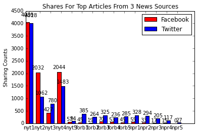

```python
ind = np.arange(N)
width = 0.35

fig, ax = plt.subplots()
facbk = ax.bar(ind, fcbkCounts, width, color='r')
twtr = ax.bar(ind+width, twtrCounts, width, color='b')

ax.set_ylabel('Sharing Counts')
ax.set_title('Shares For Top Articles From 3 News Sources')
ax.set_xticks(ind+width)

ax.set_xticklabels( ('nyt1', 'nyt2', 'nyt3', 'nyt4', 'nyt5',
                     'forb1', 'forb2', 'forb3', 'forb4', 'forb5',
                     'npr1', 'npr2', 'npr3', 'npr4', 'npr5') )

ax.legend( (facbk[0], twtr[0]), ('Facebook', 'Twitter') )

def autolabel(rects):
    # attach some text labels
    for rect in rects:
        height = rect.get_height()
        ax.text(rect.get_x()+rect.get_width()/2., 1.05*height, '%d'%int(height),
                ha='center', va='bottom')

autolabel(facbk)
autolabel(twtr)

plt.show()
```

I will now examine the OnlineNewsPopularity dataset from the UCI machine learning repository.

```python
OnlineNews = pd.read_csv("OnlineNewsPopularity.csv")
OnlineNews.keys()
TopOnlineNewsFeats = OnlineNews.sort([' shares'], ascending=False)
TopOnlineNewsFeats.index = range(len(TopOnlineNewsFeats))
```

```python
TopOnlineNewsFeats[' num_imgs']
```

```
0     15
1      0
2      1
3      0
4     11
5     18
6      0
7     21
8     14
9      0
10     0
11     1
12     0
13     1
14    11
```

[output cut: 17 more lines]

```python
TopOnlineNewsFeats[' num_videos']
```

```
0      1
1     11
2      1
3      2
4      1
5      1
6      2
7      0
8      1
9      1
10    16
11     0
12     1
13     0
14     0
```

[output cut: 17 more lines]

```python
TopOnlineNewsFeats[' num_hrefs']
```

```
0     28
1     17
2     27
3      1
4     15
5     24
6      7
7      3
8     15
9      3
10    20
11    28
12     0
13     2
14    15
```

[output cut: 17 more lines]

```
[ 593  711 1500 ..., 1900 1100 1300]
[ 55.11298203]
3144.93891919
```

```
(0, 300000)
```

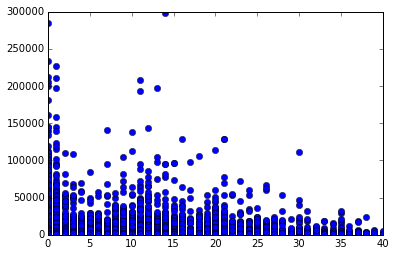

```python
from sklearn.linear_model import LinearRegression
model0 = LinearRegression(normalize=True)
ximgs = np.array(OnlineNews[' num_imgs'])
y = np.array(OnlineNews[' shares'])
Ximgs = ximgs[:, np.newaxis]
print(y)
model0.fit(Ximgs, y)
print(model0.coef_)
print(model0.intercept_)
plt.plot(ximgs, y, 'o')
plt.xlim(0, 40)
plt.ylim(0, 300000)
```

Looking at the relationship bewteen number of images and shares, there is not a great correlation. The number images appears to help increase the shares to a point. Too many images is clearly no help towards the popularity of an article. A linear model might not be appropriate here.

There are a significant amount more features in the dataset that can be used to fit a model, as oppossed to just images. The dataset also includes a number of categorial features, which could really help fit the right model.